# Tufte Handout

Toyota cars predicted value in R Markdown

Prats Jamison

2016-11-11

## Calculating with R

Before we start we will load necessary libraries

```r
library(knitr)
library(leaps)#Exhaustive search for the best of variables in x for predicting y
library(e1071)#skewness and kurotosis
library(moments)
library(broom)
library(dplyr)
library(plyr)
library(ISLR)
library(plm)
```

```r
library(lattice)
library(ggplot2)
```

To run the analysis , we need to load the data in to R

```r
#Read Data
Toyotacor <- read.csv("ToyotaCorolla.csv")
attach(Toyotacor)
summary(Toyotacor)
```

```
##      Price            Age              KM            FuelType
##  Min.   : 4350   Min.   : 1.00   Min.   :     1   Min.   :0.0000
##  1st Qu.: 8450   1st Qu.:44.00   1st Qu.: 43000   1st Qu.:1.0000
##  Median : 9900   Median :61.00   Median : 63390   Median :1.0000
##  Mean   :10731   Mean   :55.95   Mean   : 68533   Mean   :0.9039
##  3rd Qu.:11950   3rd Qu.:70.00   3rd Qu.: 87021   3rd Qu.:1.0000
##  Max.   :32500   Max.   :80.00   Max.   :243000   Max.   :2.0000
##        HP           MetColor        Automatic             CC
##  Min.   : 69.0   Min.   :0.0000   Min.   :0.00000   Min.   :1300
##  1st Qu.: 90.0   1st Qu.:0.0000   1st Qu.:0.00000   1st Qu.:1400
##  Median :110.0   Median :1.0000   Median :0.00000   Median :1600
##  Mean   :101.5   Mean   :0.6748   Mean   :0.05571   Mean   :1567
##  3rd Qu.:110.0   3rd Qu.:1.0000   3rd Qu.:0.00000   3rd Qu.:1600
##  Max.   :192.0   Max.   :1.0000   Max.   :1.00000   Max.   :2000
##      Doors           Weight
##  Min.   :2.000   Min.   :1000
##  1st Qu.:3.000   1st Qu.:1040
##  Median :4.000   Median :1070
##  Mean   :4.033   Mean   :1072
##  3rd Qu.:5.000   3rd Qu.:1085
##  Max.   :5.000   Max.   :1615
```

### Familiarize yourself with th data

```r
# Variable definition
# MPG - Miles per galon
# GPM - Galons per miles
# WT - Weight
# DIS - Dicplacement
# NC - Number of cylinders
# HP - Horsepower
# ACC - acceleration (0-60mph) in seconds
# ET - V-type engine (0) or straight (1)

head(Toyotacor)
```

```
##   Price Age    KM FuelType HP MetColor Automatic   CC Doors Weight
## 1 13500  23 46986        0 90        1         0 2000     3   1165
## 2 13750  23 72937        0 90        1         0 2000     3   1165
## 3 13950  24 41711        0 90        1         0 2000     3   1165
## 4 14950  26 48000        0 90        0         0 2000     3   1165
## 5 13750  30 38500        0 90        0         0 2000     3   1170
## 6 12950  32 61000        0 90        0         0 2000     3   1170
```

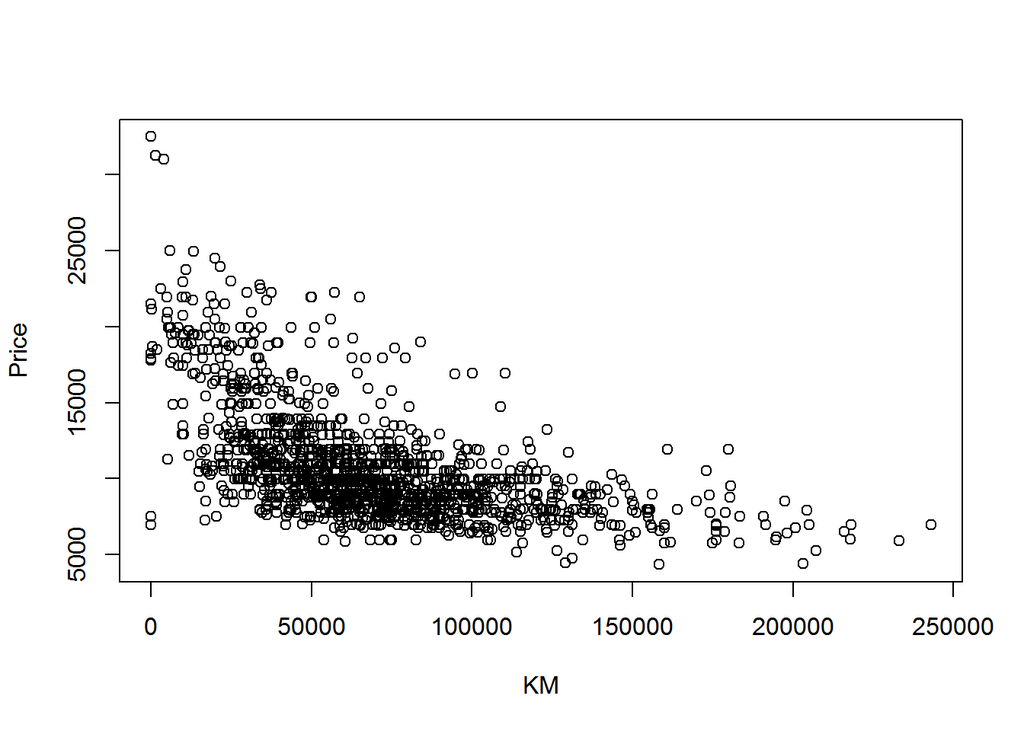

```r
 # Become familiar with the data
plot(Price ~ KM, data = Toyotacor)
```

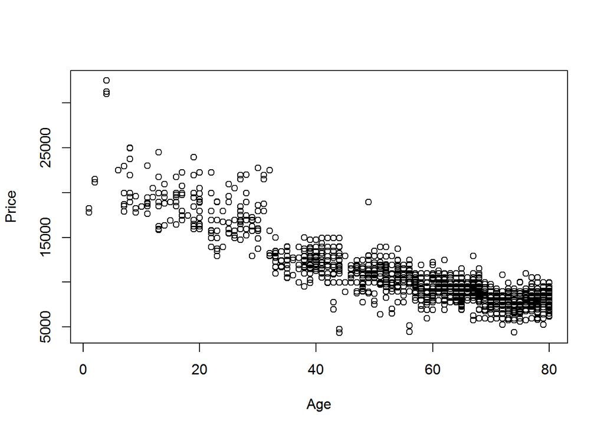

```r
plot(Price ~ Age, data = Toyotacor)
```

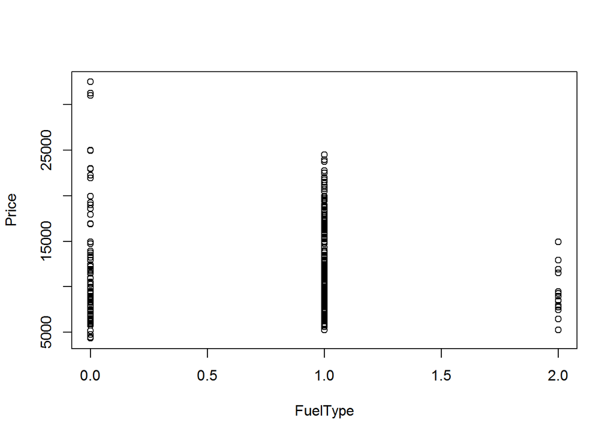

```r
plot(Price ~ FuelType, data = Toyotacor)
```

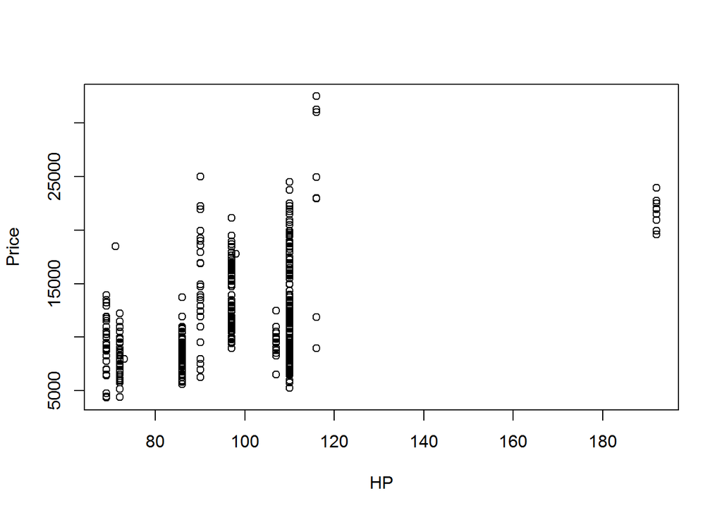

```r
plot(Price ~ HP, data = Toyotacor)
```

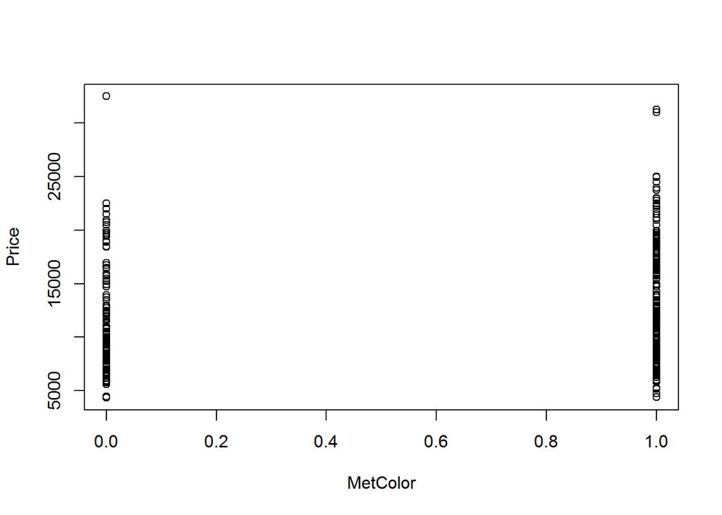

```r
plot(Price ~ MetColor, data = Toyotacor)
```

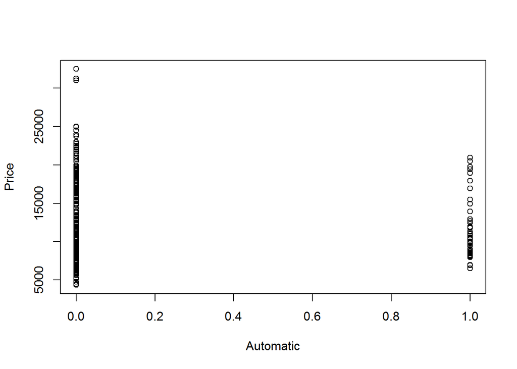

```r
plot(Price ~ Automatic, data = Toyotacor)
```

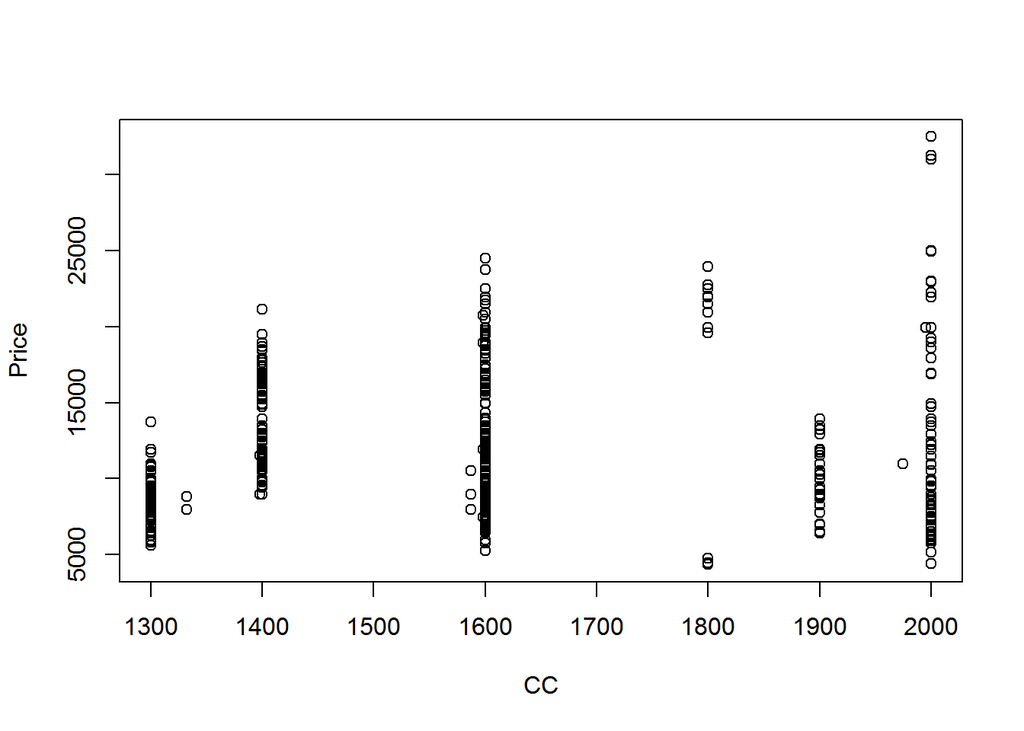

```r
plot(Price ~ CC, data = Toyotacor)
```

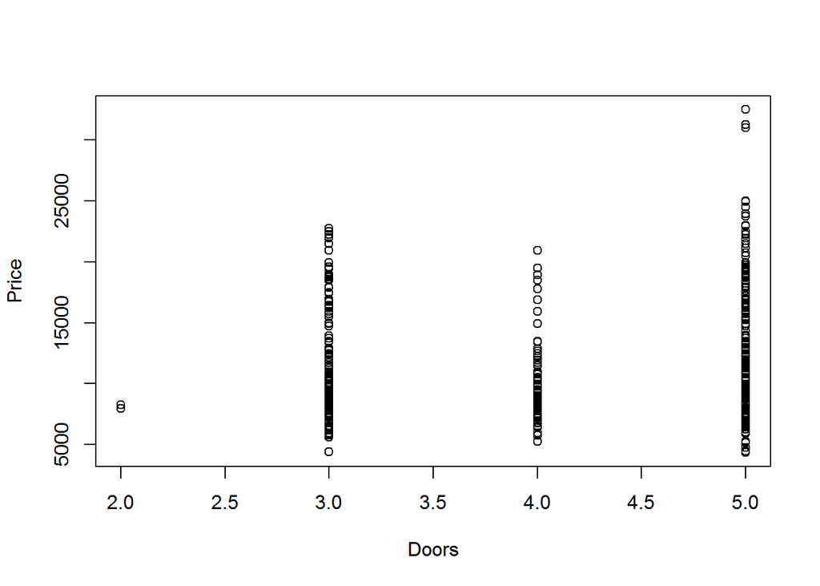

```r
plot(Price ~ Doors, data = Toyotacor)
```

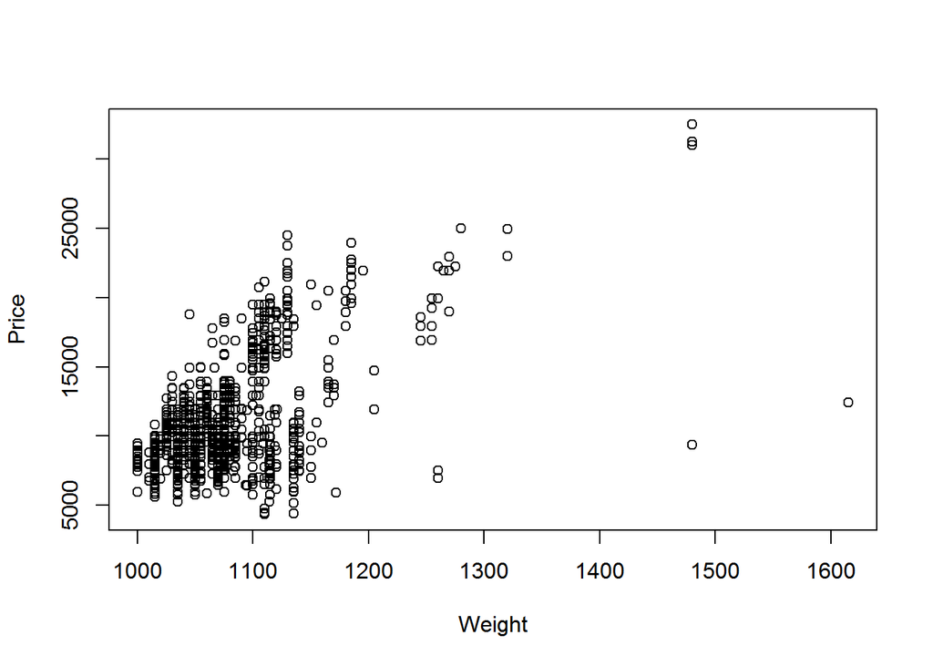

```r
plot(Price ~ Weight, data = Toyotacor)
```

### Prepare for analysis

Descriptive statistics are statistics that quantitatively describe or summarise features of a collection of information

## Linear Regression

Linear regression models are probably the most common used technique in data and buisiness analytics. They can be very powerful but one has to remember their limitations and constrains. The most important limitation is, that they should only be used to predict values within the range of the test data set. Here are are predicting the values for Toyota Coralla.

```r
# show results of first Analysis
Toyotacor.m1 <- lm(Price ~ ., data = Toyotacor)
summary(Toyotacor.m1) # Show results of the first model
```

```
##
## Call:
## lm(formula = Price ~ ., data = Toyotacor)
##
## Residuals:
##      Min       1Q   Median       3Q      Max
## -11209.6   -748.0      8.9    735.9   6374.1
##
## Coefficients:
##               Estimate Std. Error t value Pr(>|t|)
## (Intercept) -2.358e+03  1.154e+03  -2.043   0.0412 *
## Age         -1.226e+02  2.589e+00 -47.336  < 2e-16 ***
## KM          -1.567e-02  1.285e-03 -12.190  < 2e-16 ***
## FuelType    -1.555e+03  2.497e+02  -6.225 6.31e-10 ***
## HP           5.279e+01  4.084e+00  12.926  < 2e-16 ***
## MetColor     5.563e+01  7.501e+01   0.742   0.4584
## Automatic    2.905e+02  1.560e+02   1.863   0.0627 .
## CC          -3.446e+00  4.024e-01  -8.565  < 2e-16 ***
## Doors       -2.535e+01  3.910e+01  -0.648   0.5169
## Weight       2.099e+01  1.096e+00  19.151  < 2e-16 ***
## ---
## Signif. codes:  0 '***' 0.001 '**' 0.01 '*' 0.05 '.' 0.1 ' ' 1
##
## Residual standard error: 1317 on 1426 degrees of freedom
## Multiple R-squared:  0.869,  Adjusted R-squared:  0.8681
## F-statistic:  1051 on 9 and 1426 DF,  p-value: < 2.2e-16
```

```r
#Confident Interval
confint(Toyotacor.m1)
```

```
##                     2.5 %        97.5 %
## (Intercept) -4.622093e+03   -94.3881168
## Age         -1.276522e+02  -117.4931773
## KM          -1.818931e-02    -0.0131468
## FuelType    -2.044477e+03 -1064.7406133
## HP           4.477963e+01    60.8020798
## MetColor    -9.151219e+01   202.7764608
## Automatic   -1.539937e+01   596.4856405
## CC          -4.235881e+00    -2.6571199
## Doors       -1.020607e+02    51.3541562
## Weight       1.884418e+01    23.1450328
```

```r
Toyotacor.m1.confint <- confint(Toyotacor.m1)
## Check with a correlation matrix if predictor variables are themselves related
Toyotacor.D= as.data.frame(matrix(Toyotacor))[1,]
TyCo.col <- cor(data.frame(lapply(Toyotacor.D, rank)))
print(TyCo.col)
```

[output not shown]

# Calculate regression - Model 1

```r
#calculate regression - Model 1
x <- Toyotacor[, 2:10] # independent variable
x
```

```
##      Age     KM FuelType  HP MetColor Automatic   CC Doors Weight
## 1     23  46986        0  90        1         0 2000     3   1165
## 2     23  72937        0  90        1         0 2000     3   1165
## 3     24  41711        0  90        1         0 2000     3   1165
## 4     26  48000        0  90        0         0 2000     3   1165
## 5     30  38500        0  90        0         0 2000     3   1170
## 6     32  61000        0  90        0         0 2000     3   1170
## 7     27  94612        0  90        1         0 2000     3   1245
## 8     30  75889        0  90        1         0 2000     3   1245
## 9     27  19700        1 192        0         0 1800     3   1185
## 10    23  71138        0  69        0         0 1900     3   1105
## 11    25  31461        1 192        0         0 1800     3   1185
## 12    22  43610        1 192        0         0 1800     3   1185
## 13    25  32189        1 192        0         0 1800     3   1185
## 14    31  23000        1 192        1         0 1800     3   1185
```

[output cut: 1422 more lines]

```r
y <- Toyotacor[,1] # dependent variable
y
```

```
##    [1] 13500 13750 13950 14950 13750 12950 16900 18600 21500 12950 20950
##   [12] 19950 19600 21500 22500 22000 22750 17950 16750 16950 15950 16950
##   [23] 15950 16950 16250 15950 17495 15750 16950 17950 12950 15750 15950
##   [34] 14950 15500 15750 15950 14950 15750 14750 13950 16750 13950 16950
##   [45] 16950 19000 17950 15800 17950 21950 17950 15750 20500 21950 15500
##   [56] 13250 15250 15250 18950 15999 14950 16500 18750 17950 17950 16950
##   [67] 18950 14950 22250 15950 15950 12995 18950 15750 19950 16950 18750
##   [78] 18450 16895 14900 18950 17250 15450 17950 16650 17450 14900 17950
##   [89] 15950 21950 16450 22250 19950 15950 18900 19950 15950 15950 18750
##  [100] 17450 18990 16250 18500 18500 19450 16950 18800 17450 17950 32500
##  [111] 31000 31275 24950 24950 22950 24990 21950 17900 19250 22250 18950
##  [122] 19950 16350 18950 16950 21750 15950 16500 17950 15850 16250 15950
##  [133] 16250 15950 16500 16500 18450 16250 23000 19900 16450 23950 19950
##  [144] 18500 18950 16450 20500 24500 19450 20950 17200 19950 18450 19500
##  [155] 21750 16868 19500 18900 19750 19750 18950 20750 19600 19500 17650
```

[output cut: 116 more lines]

```r
#model selection
Toyotacor.out <- summary(regsubsets(x,y, nbest = 2, nvmax = ncol(x)))
Toyotacor.regtab <- cbind(Toyotacor.out$which, Toyotacor.out$rsq, Toyotacor.out$adjr2, Toyotacor.out$cp)

colnames(Toyotacor.regtab) <- c("(Intercept)", "Age", "KM", "FuelType", "HP", "MetColor", "Transmission", "CC" , "Doors", "Weight", "R-Sq", "R-Sq(adj)", "Cp")
print(Toyotacor.regtab) # pValue is < 0.05, so we reject null hypothesis
```

```
##   (Intercept) Age KM FuelType HP MetColor Transmission CC Doors Weight
## 1           1   1  0        0  0        0            0  0     0      0
## 1           1   0  0        0  0        0            0  0     0      1
## 2           1   1  0        0  0        0            0  0     0      1
## 2           1   1  0        0  1        0            0  0     0      0
## 3           1   1  1        0  0        0            0  0     0      1
## 3           1   1  0        0  1        0            0  0     0      1
## 4           1   1  1        0  1        0            0  0     0      1
## 4           1   1  1        1  0        0            0  0     0      1
## 5           1   1  1        0  1        0            0  1     0      1
## 5           1   1  1        0  1        0            1  0     0      1
## 6           1   1  1        1  1        0            0  1     0      1
## 6           1   1  1        0  1        0            0  1     1      1
## 7           1   1  1        1  1        0            1  1     0      1
## 7           1   1  1        1  1        0            0  1     1      1
```

[output cut: 21 more lines]

### Regression analysis with the given variable 7 expect km and windows and also find the car cost using these variables

```r
#create second model
Toyotacor.m2 <- lm(Price~ Age + FuelType+HP+MetColor+ Automatic+ CC + Doors, data = Toyotacor) #just with weight
Toyotacor.m2.summary <- summary(Toyotacor.m2)
print(Toyotacor.m2.summary)
```

```
##
## Call:
## lm(formula = Price ~ Age + FuelType + HP + MetColor + Automatic +
##     CC + Doors, data = Toyotacor)
##
## Residuals:
##     Min      1Q  Median      3Q     Max
## -7743.0  -917.8    -2.5   845.8 10889.1
##
## Coefficients:
##               Estimate Std. Error t value Pr(>|t|)
## (Intercept) 18013.1737   653.1245  27.580  < 2e-16 ***
## Age          -158.7395     2.2938 -69.203  < 2e-16 ***
## FuelType    -2983.6858   281.3298 -10.606  < 2e-16 ***
## HP             80.1797     4.4713  17.932  < 2e-16 ***
## MetColor       69.5683    87.2992   0.797    0.426
## Automatic    1059.8909   177.2514   5.980 2.82e-09 ***
## CC             -3.0006     0.4238  -7.080 2.26e-12 ***
## Doors         186.6019    43.5539   4.284 1.95e-05 ***
## ---
## Signif. codes:  0 '***' 0.001 '**' 0.01 '*' 0.05 '.' 0.1 ' ' 1
##
## Residual standard error: 1534 on 1428 degrees of freedom
## Multiple R-squared:  0.822,  Adjusted R-squared:  0.8211
## F-statistic: 941.8 on 7 and 1428 DF,  p-value: < 2.2e-16
```

```r
#Model 2 Conf Intervals
Toyotacor.m2.confint <- confint(Toyotacor.m2)
print(Toyotacor.m2.confint)
```

```
##                    2.5 %       97.5 %
## (Intercept) 16731.987223 19294.360128
## Age          -163.239073  -154.239859
## FuelType    -3535.549866 -2431.821782
## HP             71.408754    88.950692
## MetColor     -101.680116   240.816723
## Automatic     712.189858  1407.591937
## CC             -3.832028    -2.169183
## Doors         101.165454   272.038356
```

```r
Toyotacor.m2 <- lm(Price~ Age + FuelType+HP+MetColor+ Automatic+ CC + Doors, data = Toyotacor)
Toyotacor.m2
```

```
##
## Call:
## lm(formula = Price ~ Age + FuelType + HP + MetColor + Automatic +
##     CC + Doors, data = Toyotacor)
##
## Coefficients:
## (Intercept)          Age     FuelType           HP     MetColor
##   18013.174     -158.739    -2983.686       80.180       69.568
##   Automatic           CC        Doors
##    1059.891       -3.001      186.602
```

```r
#Assigning values
given.Toyotacor <- data.frame(Age=12, FuelType=1, HP=185, MetColor=1, Automatic=0, CC=2000, Doors=4)
predicted.price <- predict(Toyotacor.m2,given.Toyotacor)
print(predicted.price)# Predicted Car Value
```

```
##        1
## 22772.63
```

```r
#predicted Values/ Residuals
Toyotaco_hat <- fitted(Toyotacor.m1)# predicted values
as.data.frame(Toyotaco_hat)
```

```
##      Toyotaco_hat
## 1       16382.873
## 2       15976.272
## 3       16342.950
## 4       15943.636
## 5       15707.164
## 6       15109.488
## 7       16825.944
## 8       16751.579
## 9       21203.719
## 10      13925.192
## 11      21264.593
## 12      21441.960
## 13      21253.186
## 14      20717.356
```

[output cut: 1422 more lines]

```r
Toyota_resid <- residuals(Toyotacor.m1) # residuals
as.data.frame(Toyota_resid)
```

```
##       Toyota_resid
## 1    -2.882873e+03
## 2    -2.226272e+03
## 3    -2.392950e+03
## 4    -9.936356e+02
## 5    -1.957164e+03
## 6    -2.159488e+03
## 7     7.405566e+01
## 8     1.848421e+03
## 9     2.962806e+02
## 10   -9.751920e+02
## 11   -3.145928e+02
## 12   -1.491960e+03
## 13   -1.653186e+03
## 14    7.826438e+02
```

[output cut: 1422 more lines]

```r
n <- length(Toyotacor$Price)
diff <- dim(n)
percdiff <- dim(n)
for (k in 1:n) {
  train1 <- c(1:n)
  train <- train1[train1 !=k ]
  m2 <- lm(Price~ ., data = Toyotacor[train,])
  pred <- predict(m2, newdat = Toyotacor[-train,])
  obs <- Toyotacor$Price[-train]
  diff[k] <- obs - pred
  percdiff[k] <- abs(diff[k]) / obs
}
Toyotacor.m2.me <- mean(diff)
Toyotacor.m2.rmse <- sqrt(mean(diff**2))
Toyotacor.m2.mape <- 100*(mean(percdiff))

Toyotacor.m2.me
```

```
## [1] -1.842833
```

```r
Toyotacor.m2.rmse
```

```
## [1] 1350.015
```

```r
Toyotacor.m2.mape
```

```
## [1] 9.53237
```

```r
predicted.price
```

```
##        1
## 22772.63
```

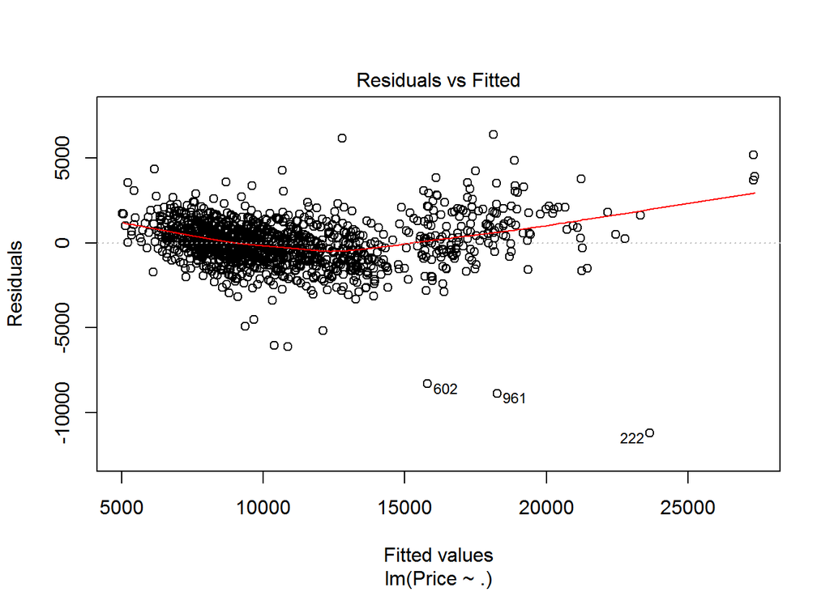

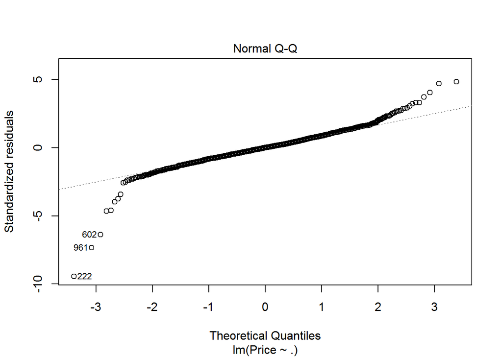

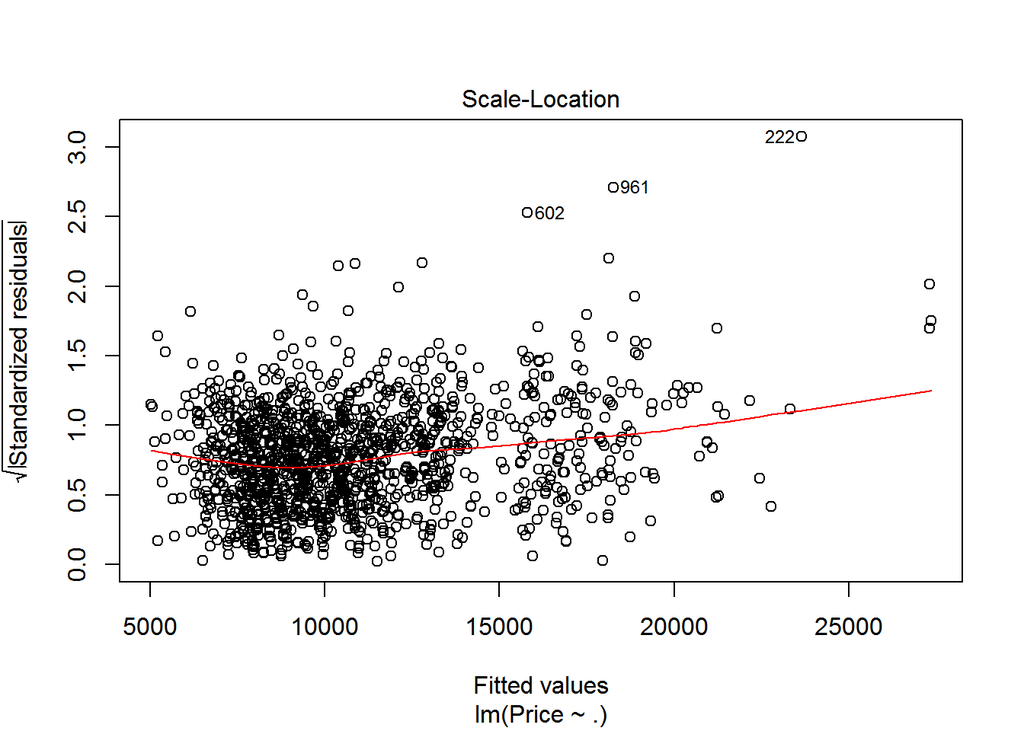

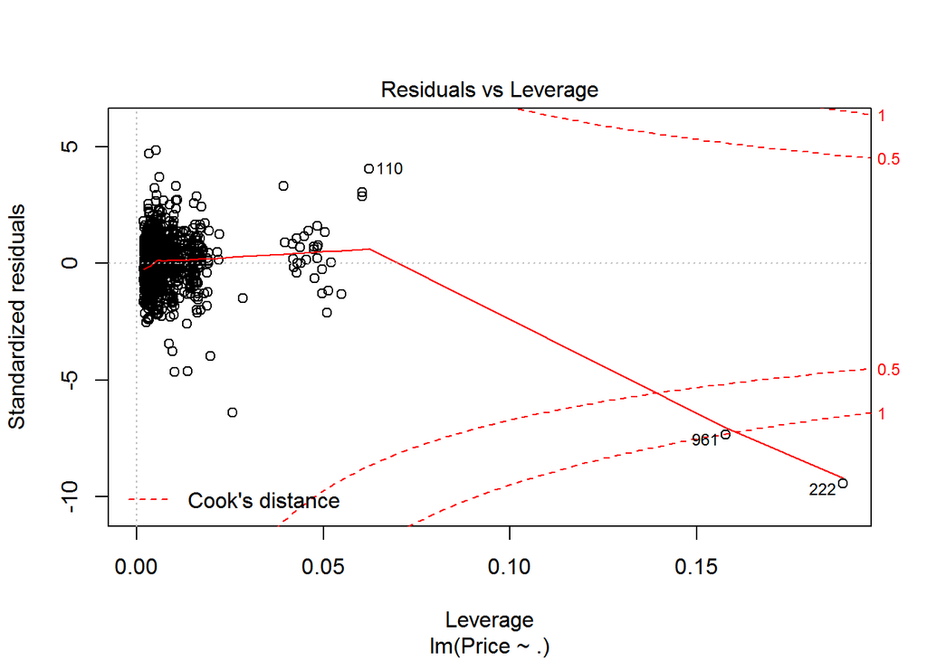

```r
#check if assumptions are met...
plot(Toyotacor.m1)
```

```r
ggsave("HW3 Graph/ToyotaCorlin.pdf")
```